# 第8讲 相关回归分析

2023-12-08

# **视频资源**

- [SPSS 相关系数矩阵](https://www.bilibili.com/video/BV1Pw411878L/)
- [SPSS 回归分析](https://www.bilibili.com/video/BV1QK41137Sf/)
- SPSS 时间序列趋势分析
- SPSS 复合型时间序列因素分解

# **习题**

用SPSS完成下列要求：

1. 绘制月租金（自变量）和出租率（因变量）的散点图。
2. 报告月租金（自变量）和出租率（因变量）的相关系数矩阵。
3. 建立月租金（自变量）和出租率（因变量）之间的一元回归模型，报告回归分析的输出结果，写出估计的回归方程。
4. 解释一元回归模型中斜率系数的含义。
5. 一元回归模型的判定系数（R平方）是多少？

[figure not shown]

## 时间序列线性趋势分析——教材例题13.7，P281

用SPSS完成下列要求：

1. 报告发电量的线性趋势方程。
2. 根据估计的线性趋势方程计算各个年份发电量的预测值, 计算各个年份发电量的观测值和预测值的差（残差，残差=被解释变量的观测值-被解释变量的估计值）。
3. 绘制各个年份发电量的观测值和预测值的时序图。

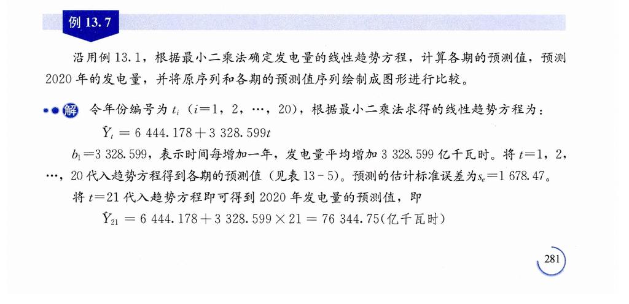

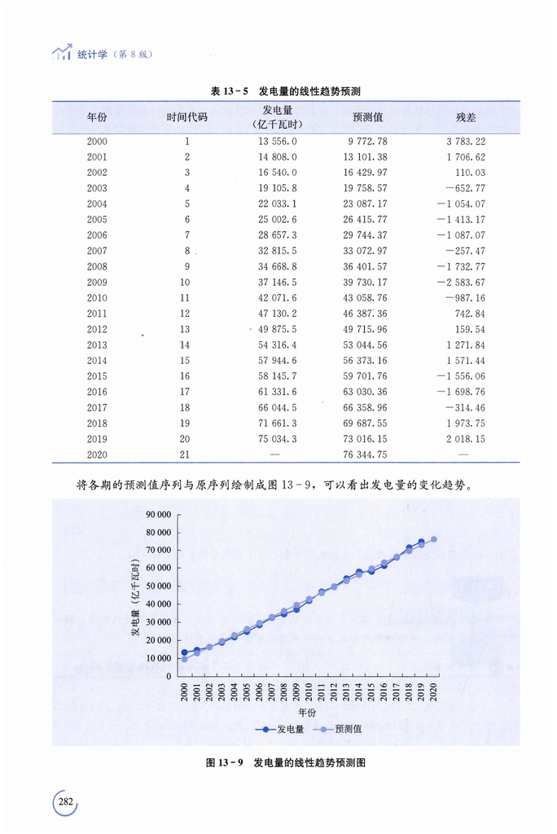

## 时间序列非线性趋势分析——教材例题13.9，P285

用SPSS完成下列要求：

1. 报告轿车产量的二阶曲线方程。
2. 报告轿车产量的三阶曲线方程。
3. 绘制如教材P286图13-11的图形。

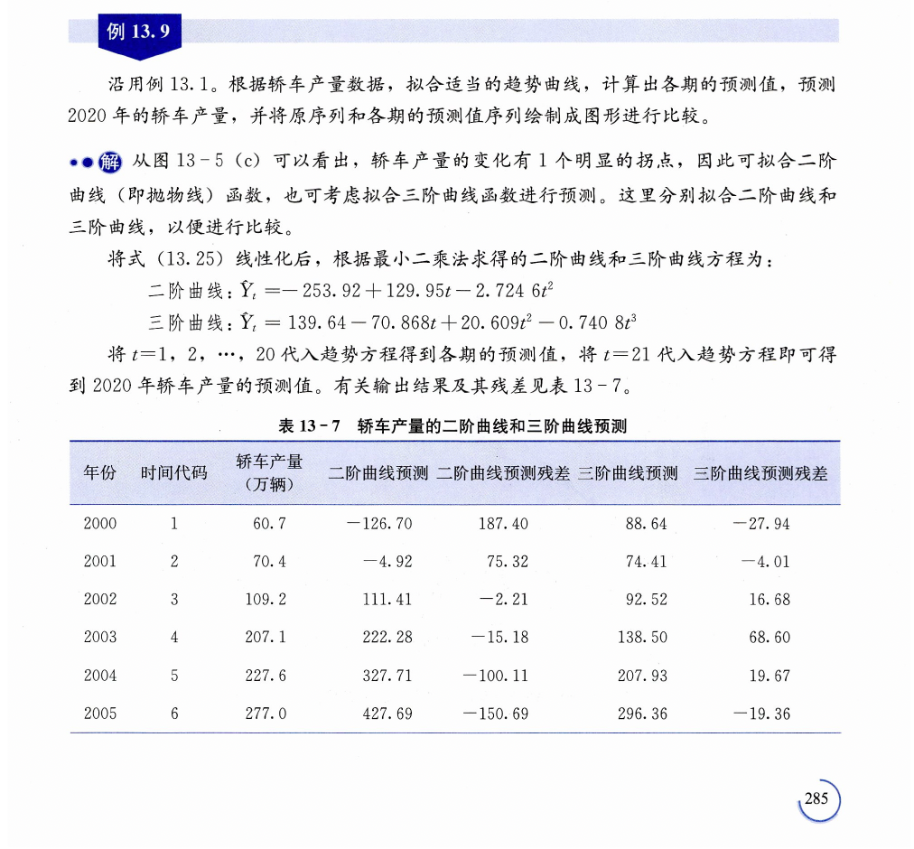

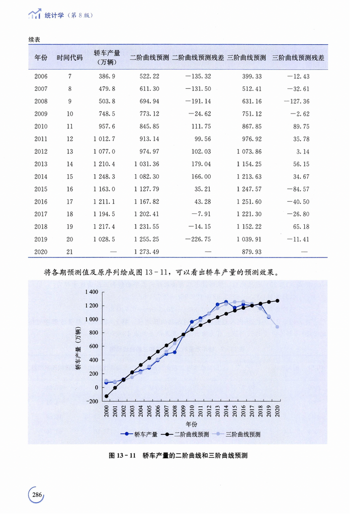